# quantium data science

## Quantium Task1

#### By Samuel Waweru, Mechatronic Engineering Undergraduate 2025.

Analysis of Customer Data and data visualization. Quantium’s retail analytics team :Chips and their purchasing behaviour within the region.

```python
#importing libraries
import pandas as pd
import numpy as np
import matplotlib.pyplot as plt
```

```python
df=pd.read_csv("S:\code\Quantium_proj\QVI_purchase_behaviour.csv")
# to output the first 30 items
df.head(30)
```

|  | LYLTY_CARD_NBR | LIFESTAGE | PREMIUM_CUSTOMER |
| --- | --- | --- | --- |
| 0 | 1000 | YOUNG SINGLES/COUPLES | Premium |
| 1 | 1002 | YOUNG SINGLES/COUPLES | Mainstream |
| 2 | 1003 | YOUNG FAMILIES | Budget |
| 3 | 1004 | OLDER SINGLES/COUPLES | Mainstream |
| 4 | 1005 | MIDAGE SINGLES/COUPLES | Mainstream |
| 5 | 1007 | YOUNG SINGLES/COUPLES | Budget |
| 6 | 1009 | NEW FAMILIES | Premium |
| 7 | 1010 | YOUNG SINGLES/COUPLES | Mainstream |
| 8 | 1011 | OLDER SINGLES/COUPLES | Mainstream |
| 9 | 1012 | OLDER FAMILIES | Mainstream |
| 10 | 1013 | RETIREES | Budget |
| 11 | 1016 | OLDER FAMILIES | Mainstream |
| 12 | 1018 | YOUNG SINGLES/COUPLES | Mainstream |
| 13 | 1019 | OLDER SINGLES/COUPLES | Premium |
| 14 | 1020 | YOUNG SINGLES/COUPLES | Mainstream |
| 15 | 1022 | OLDER FAMILIES | Budget |
| 16 | 1023 | MIDAGE SINGLES/COUPLES | Premium |
| 17 | 1024 | YOUNG SINGLES/COUPLES | Premium |
| 18 | 1025 | YOUNG FAMILIES | Budget |
| 19 | 1026 | MIDAGE SINGLES/COUPLES | Premium |
| 20 | 1027 | OLDER FAMILIES | Premium |
| 21 | 1028 | YOUNG SINGLES/COUPLES | Budget |
| 22 | 1030 | RETIREES | Mainstream |
| 23 | 1034 | RETIREES | Premium |
| 24 | 1038 | OLDER FAMILIES | Mainstream |
| 25 | 1039 | YOUNG FAMILIES | Mainstream |
| 26 | 1042 | YOUNG SINGLES/COUPLES | Premium |
| 27 | 1043 | YOUNG FAMILIES | Budget |
| 28 | 1044 | YOUNG FAMILIES | Mainstream |
| 29 | 1046 | YOUNG SINGLES/COUPLES | Budget |

```python
df1=pd.read_csv("QVI_transaction_data.csv")
# to output the first 30 items
df1.head(30)
```

|  | DATE | STORE_NBR | LYLTY_CARD_NBR | TXN_ID | PROD_NBR | PROD_NAME | PROD_QTY | TOT_SALES |
| --- | --- | --- | --- | --- | --- | --- | --- | --- |
| 0 | 43390 | 1 | 1000 | 1 | 5 | Natural Chip Compny SeaSalt175g | 2 | 6.0 |
| 1 | 43599 | 1 | 1307 | 348 | 66 | CCs Nacho Cheese 175g | 3 | 6.3 |
| 2 | 43605 | 1 | 1343 | 383 | 61 | Smiths Crinkle Cut Chips Chicken 170g | 2 | 2.9 |
| 3 | 43329 | 2 | 2373 | 974 | 69 | Smiths Chip Thinly S/Cream&Onion 175g | 5 | 15.0 |
| 4 | 43330 | 2 | 2426 | 1038 | 108 | Kettle Tortilla ChpsHny&Jlpno Chili 150g | 3 | 13.8 |
| 5 | 43604 | 4 | 4074 | 2982 | 57 | Old El Paso Salsa Dip Tomato Mild 300g | 1 | 5.1 |
| 6 | 43601 | 4 | 4149 | 3333 | 16 | Smiths Crinkle Chips Salt & Vinegar 330g | 1 | 5.7 |
| 7 | 43601 | 4 | 4196 | 3539 | 24 | Grain Waves Sweet Chilli 210g | 1 | 3.6 |
| 8 | 43332 | 5 | 5026 | 4525 | 42 | Doritos Corn Chip Mexican Jalapeno 150g | 1 | 3.9 |
| 9 | 43330 | 7 | 7150 | 6900 | 52 | Grain Waves Sour Cream&Chives 210G | 2 | 7.2 |
| 10 | 43602 | 7 | 7215 | 7176 | 16 | Smiths Crinkle Chips Salt & Vinegar 330g | 1 | 5.7 |
| 11 | 43332 | 8 | 8294 | 8221 | 114 | Kettle Sensations Siracha Lime 150g | 5 | 23.0 |
| 12 | 43603 | 9 | 9208 | 8634 | 15 | Twisties Cheese 270g | 2 | 9.2 |
| 13 | 43329 | 13 | 13213 | 12447 | 92 | WW Crinkle Cut Chicken 175g | 1 | 1.7 |
| 14 | 43600 | 19 | 19272 | 16686 | 44 | Thins Chips Light& Tangy 175g | 1 | 3.3 |
| 15 | 43604 | 20 | 20164 | 17136 | 54 | CCs Original 175g | 1 | 2.1 |
| 16 | 43330 | 20 | 20418 | 17413 | 94 | Burger Rings 220g | 4 | 9.2 |
| 17 | 43326 | 22 | 22411 | 18646 | 98 | NCC Sour Cream & Garden Chives 175g | 1 | 3.0 |
| 18 | 43329 | 22 | 22456 | 18696 | 93 | Doritos Corn Chip Southern Chicken 150g | 1 | 3.9 |
| 19 | 43601 | 23 | 23067 | 19162 | 56 | Cheezels Cheese Box 125g | 1 | 2.1 |
| 20 | 43604 | 25 | 25105 | 21815 | 7 | Smiths Crinkle Original 330g | 1 | 5.7 |
| 21 | 43328 | 33 | 33081 | 29949 | 98 | NCC Sour Cream & Garden Chives 175g | 1 | 3.0 |
| 22 | 43328 | 36 | 36012 | 32077 | 31 | Infzns Crn Crnchers Tangy Gcamole 110g | 1 | 3.8 |
| 23 | 43331 | 36 | 36302 | 33188 | 32 | Kettle Sea Salt And Vinegar 175g | 1 | 5.4 |
| 24 | 43327 | 38 | 38142 | 34181 | 108 | Kettle Tortilla ChpsHny&Jlpno Chili 150g | 2 | 9.2 |
| 25 | 43600 | 39 | 39144 | 35506 | 57 | Old El Paso Salsa Dip Tomato Mild 300g | 1 | 5.1 |
| 26 | 43331 | 39 | 39167 | 35638 | 111 | Smiths Chip Thinly Cut Original 175g | 2 | 6.0 |
| 27 | 43600 | 41 | 41423 | 38393 | 46 | Kettle Original 175g | 1 | 5.4 |
| 28 | 43327 | 41 | 41486 | 38472 | 13 | Red Rock Deli Thai Chilli&Lime 150g | 1 | 2.7 |
| 29 | 43605 | 43 | 43110 | 39342 | 31 | Infzns Crn Crnchers Tangy Gcamole 110g | 1 | 3.8 |

### Data Cleaning

Examine transaction data – look for inconsistencies, missing data across the data set, outliers, correctly identified category items,numeric data across all tables. If you determine any anomalies make the necessary changes in the dataset and save it.Having clean data will help when it comes to your analysis.

```python
#Data Frame df
df1.dropna(inplace = True)
df1.head(30)
```

|  | DATE | STORE_NBR | LYLTY_CARD_NBR | TXN_ID | PROD_NBR | PROD_NAME | PROD_QTY | TOT_SALES |
| --- | --- | --- | --- | --- | --- | --- | --- | --- |
| 0 | 43390 | 1 | 1000 | 1 | 5 | Natural Chip Compny SeaSalt175g | 2 | 6.0 |
| 1 | 43599 | 1 | 1307 | 348 | 66 | CCs Nacho Cheese 175g | 3 | 6.3 |
| 2 | 43605 | 1 | 1343 | 383 | 61 | Smiths Crinkle Cut Chips Chicken 170g | 2 | 2.9 |
| 3 | 43329 | 2 | 2373 | 974 | 69 | Smiths Chip Thinly S/Cream&Onion 175g | 5 | 15.0 |
| 4 | 43330 | 2 | 2426 | 1038 | 108 | Kettle Tortilla ChpsHny&Jlpno Chili 150g | 3 | 13.8 |
| 5 | 43604 | 4 | 4074 | 2982 | 57 | Old El Paso Salsa Dip Tomato Mild 300g | 1 | 5.1 |
| 6 | 43601 | 4 | 4149 | 3333 | 16 | Smiths Crinkle Chips Salt & Vinegar 330g | 1 | 5.7 |
| 7 | 43601 | 4 | 4196 | 3539 | 24 | Grain Waves Sweet Chilli 210g | 1 | 3.6 |
| 8 | 43332 | 5 | 5026 | 4525 | 42 | Doritos Corn Chip Mexican Jalapeno 150g | 1 | 3.9 |
| 9 | 43330 | 7 | 7150 | 6900 | 52 | Grain Waves Sour Cream&Chives 210G | 2 | 7.2 |
| 10 | 43602 | 7 | 7215 | 7176 | 16 | Smiths Crinkle Chips Salt & Vinegar 330g | 1 | 5.7 |
| 11 | 43332 | 8 | 8294 | 8221 | 114 | Kettle Sensations Siracha Lime 150g | 5 | 23.0 |
| 12 | 43603 | 9 | 9208 | 8634 | 15 | Twisties Cheese 270g | 2 | 9.2 |
| 13 | 43329 | 13 | 13213 | 12447 | 92 | WW Crinkle Cut Chicken 175g | 1 | 1.7 |
| 14 | 43600 | 19 | 19272 | 16686 | 44 | Thins Chips Light& Tangy 175g | 1 | 3.3 |
| 15 | 43604 | 20 | 20164 | 17136 | 54 | CCs Original 175g | 1 | 2.1 |
| 16 | 43330 | 20 | 20418 | 17413 | 94 | Burger Rings 220g | 4 | 9.2 |
| 17 | 43326 | 22 | 22411 | 18646 | 98 | NCC Sour Cream & Garden Chives 175g | 1 | 3.0 |
| 18 | 43329 | 22 | 22456 | 18696 | 93 | Doritos Corn Chip Southern Chicken 150g | 1 | 3.9 |
| 19 | 43601 | 23 | 23067 | 19162 | 56 | Cheezels Cheese Box 125g | 1 | 2.1 |
| 20 | 43604 | 25 | 25105 | 21815 | 7 | Smiths Crinkle Original 330g | 1 | 5.7 |
| 21 | 43328 | 33 | 33081 | 29949 | 98 | NCC Sour Cream & Garden Chives 175g | 1 | 3.0 |
| 22 | 43328 | 36 | 36012 | 32077 | 31 | Infzns Crn Crnchers Tangy Gcamole 110g | 1 | 3.8 |
| 23 | 43331 | 36 | 36302 | 33188 | 32 | Kettle Sea Salt And Vinegar 175g | 1 | 5.4 |
| 24 | 43327 | 38 | 38142 | 34181 | 108 | Kettle Tortilla ChpsHny&Jlpno Chili 150g | 2 | 9.2 |
| 25 | 43600 | 39 | 39144 | 35506 | 57 | Old El Paso Salsa Dip Tomato Mild 300g | 1 | 5.1 |
| 26 | 43331 | 39 | 39167 | 35638 | 111 | Smiths Chip Thinly Cut Original 175g | 2 | 6.0 |
| 27 | 43600 | 41 | 41423 | 38393 | 46 | Kettle Original 175g | 1 | 5.4 |
| 28 | 43327 | 41 | 41486 | 38472 | 13 | Red Rock Deli Thai Chilli&Lime 150g | 1 | 2.7 |
| 29 | 43605 | 43 | 43110 | 39342 | 31 | Infzns Crn Crnchers Tangy Gcamole 110g | 1 | 3.8 |

Examine customer data – check for similar issues in the customer data, look for nulls and when you are happy merge the transaction and customer data together so it’s ready for the analysis ensuring you save your files along the way.

```python
#Data Frame df
df.dropna(inplace = True)
df.head(30)
```

|  | LYLTY_CARD_NBR | LIFESTAGE | PREMIUM_CUSTOMER |
| --- | --- | --- | --- |
| 0 | 1000 | YOUNG SINGLES/COUPLES | Premium |
| 1 | 1002 | YOUNG SINGLES/COUPLES | Mainstream |
| 2 | 1003 | YOUNG FAMILIES | Budget |
| 3 | 1004 | OLDER SINGLES/COUPLES | Mainstream |
| 4 | 1005 | MIDAGE SINGLES/COUPLES | Mainstream |
| 5 | 1007 | YOUNG SINGLES/COUPLES | Budget |
| 6 | 1009 | NEW FAMILIES | Premium |
| 7 | 1010 | YOUNG SINGLES/COUPLES | Mainstream |
| 8 | 1011 | OLDER SINGLES/COUPLES | Mainstream |
| 9 | 1012 | OLDER FAMILIES | Mainstream |
| 10 | 1013 | RETIREES | Budget |
| 11 | 1016 | OLDER FAMILIES | Mainstream |
| 12 | 1018 | YOUNG SINGLES/COUPLES | Mainstream |
| 13 | 1019 | OLDER SINGLES/COUPLES | Premium |
| 14 | 1020 | YOUNG SINGLES/COUPLES | Mainstream |
| 15 | 1022 | OLDER FAMILIES | Budget |
| 16 | 1023 | MIDAGE SINGLES/COUPLES | Premium |
| 17 | 1024 | YOUNG SINGLES/COUPLES | Premium |
| 18 | 1025 | YOUNG FAMILIES | Budget |
| 19 | 1026 | MIDAGE SINGLES/COUPLES | Premium |
| 20 | 1027 | OLDER FAMILIES | Premium |
| 21 | 1028 | YOUNG SINGLES/COUPLES | Budget |
| 22 | 1030 | RETIREES | Mainstream |
| 23 | 1034 | RETIREES | Premium |
| 24 | 1038 | OLDER FAMILIES | Mainstream |
| 25 | 1039 | YOUNG FAMILIES | Mainstream |
| 26 | 1042 | YOUNG SINGLES/COUPLES | Premium |
| 27 | 1043 | YOUNG FAMILIES | Budget |
| 28 | 1044 | YOUNG FAMILIES | Mainstream |
| 29 | 1046 | YOUNG SINGLES/COUPLES | Budget |

```python
# merging the two DataFrame
frames = [df, df1]
result = pd.concat(frames)
result
```

|  | LYLTY_CARD_NBR | LIFESTAGE | PREMIUM_CUSTOMER | DATE | STORE_NBR | TXN_ID | PROD_NBR | PROD_NAME | PROD_QTY | TOT_SALES |
| --- | --- | --- | --- | --- | --- | --- | --- | --- | --- | --- |
| 0 | 1000 | YOUNG SINGLES/COUPLES | Premium | NaN | NaN | NaN | NaN | NaN | NaN | NaN |
| 1 | 1002 | YOUNG SINGLES/COUPLES | Mainstream | NaN | NaN | NaN | NaN | NaN | NaN | NaN |
| 2 | 1003 | YOUNG FAMILIES | Budget | NaN | NaN | NaN | NaN | NaN | NaN | NaN |
| 3 | 1004 | OLDER SINGLES/COUPLES | Mainstream | NaN | NaN | NaN | NaN | NaN | NaN | NaN |
| 4 | 1005 | MIDAGE SINGLES/COUPLES | Mainstream | NaN | NaN | NaN | NaN | NaN | NaN | NaN |
| ... | ... | ... | ... | ... | ... | ... | ... | ... | ... | ... |
| 264831 | 272319 | NaN | NaN | 43533.0 | 272.0 | 270088.0 | 89.0 | Kettle Sweet Chilli And Sour Cream 175g | 2.0 | 10.8 |
| 264832 | 272358 | NaN | NaN | 43325.0 | 272.0 | 270154.0 | 74.0 | Tostitos Splash Of Lime 175g | 1.0 | 4.4 |
| 264833 | 272379 | NaN | NaN | 43410.0 | 272.0 | 270187.0 | 51.0 | Doritos Mexicana 170g | 2.0 | 8.8 |
| 264834 | 272379 | NaN | NaN | 43461.0 | 272.0 | 270188.0 | 42.0 | Doritos Corn Chip Mexican Jalapeno 150g | 2.0 | 7.8 |
| 264835 | 272380 | NaN | NaN | 43365.0 | 272.0 | 270189.0 | 74.0 | Tostitos Splash Of Lime 175g | 2.0 | 8.8 |

337473 rows × 10 columns

Data analysis and customer segments – in your analysis make sure you define the metrics – look at total sales, drivers of sales, where the highest sales are coming from etc. Explore the data, create charts and graphs as well as noting any interesting trends and/or insights you find. These will all form part of our report to Julia.

[figure not shown]

```python
#Graphs

#Graph 1: Product Quality vs Total Sales

x = result.TOT_SALES
y = result.PROD_QTY

fig = plt.figure()
ax = fig.add_subplot(111)
ax.plot(x, y, color='lightblue', linewidth=3)

ax.scatter([2,4,6],[5,15,25],color='darkgreen',marker='^')

ax.set_xlim(1, 6.5)
ax.set_xlabel('Total Sales')
ax.set_ylabel('Product Quality')
ax.set_title('Product Quality Vs Total Sales')
plt.savefig('Graph.png')

plt.show()
```

```
PREMIUM_CUSTOMER
Budget        24470
Mainstream    29245
Premium       18922
Name: PREMIUM_CUSTOMER, dtype: int64
```

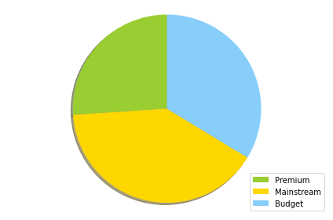

```python
# Graph 2:The number of clients according to choices
print(result.groupby(['PREMIUM_CUSTOMER'])['PREMIUM_CUSTOMER'].count())
Premium =result['PREMIUM_CUSTOMER'].str.contains('Premium').value_counts()[True] #18922
Mainstream = result['PREMIUM_CUSTOMER'].str.contains('Mainstream').value_counts()[True] #29245
Budget = result['PREMIUM_CUSTOMER'].str.contains('Budget').value_counts()[True] #18922

labels = ['Premium', 'Mainstream', 'Budget']
sizes = [Premium, Mainstream, Budget]
colors = ['yellowgreen', 'gold', 'lightskyblue']
patches, texts = plt.pie(sizes, colors=colors, shadow=True, startangle=90)
plt.legend(patches, labels, loc="best")
plt.axis('equal')
plt.tight_layout()
plt.show()
```

```
LIFESTAGE
MIDAGE SINGLES/COUPLES     7275
NEW FAMILIES               2549
OLDER FAMILIES             9780
OLDER SINGLES/COUPLES     14609
RETIREES                  14805
YOUNG FAMILIES             9178
YOUNG SINGLES/COUPLES     14441
Name: LIFESTAGE, dtype: int64
```

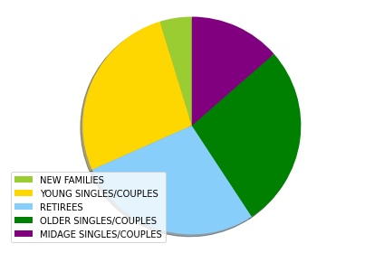

```python
# Graph 3:Lifestage Group count graphs
print(result.groupby(['LIFESTAGE'])['LIFESTAGE'].count())
NEW_FAMILIES =result['LIFESTAGE'].str.contains('NEW FAMILIES').value_counts()[True]
YOUNG_SINGLES_COUPLES = result['LIFESTAGE'].str.contains('YOUNG SINGLES/COUPLES').value_counts()[True]
RETIREES = result['LIFESTAGE'].str.contains('RETIREES').value_counts()[True]
OLDER_SINGLES_COUPLES = result['LIFESTAGE'].str.contains('OLDER SINGLES/COUPLES').value_counts()[True]
MIDAGE_SINGLES_COUPLES = result['LIFESTAGE'].str.contains('MIDAGE SINGLES/COUPLES').value_counts()[True]

labels = ['NEW FAMILIES', 'YOUNG SINGLES/COUPLES', 'RETIREES','OLDER SINGLES/COUPLES','MIDAGE SINGLES/COUPLES']
sizes = [NEW_FAMILIES,YOUNG_SINGLES_COUPLES, RETIREES,OLDER_SINGLES_COUPLES, MIDAGE_SINGLES_COUPLES]
colors = ['yellowgreen', 'gold', 'lightskyblue','green','purple']
patches, texts = plt.pie(sizes, colors=colors, shadow=True, startangle=90)
plt.legend(patches, labels, loc="best")
plt.axis('equal')
plt.tight_layout()
plt.show()
```